# Impact of Weather Events on Life and Economy

## Synopsis

This is the second assignment of the course ‘Reproducible Research’. Storms and other severe weather events can cause both public health and economic problems for communities and municipalities. Many severe events can result in fatalities, injuries, and property damage, and preventing such outcomes to the extent possible is a key concern. For the purpose of this assignment we will be analysing the weather data available in the United States and predicting which conditions result in the highest loss of life and economy. The analysis of the data shows that tornadoes, by far, have the greatest health impact as measured by the number of injuries and fatalities The analysis also shows that floods cause the greatest economic impact as measured by property damage and crop damage.

## Data Processing

### Loading Libraries

Following libraries were used for the analysis

```r
library(ggplot2)
library(plyr)
library(dplyr)
```

### Data

Loading the data

```r
if(!exists("storm.data")) {
      storm.data<- read.csv(bzfile("storm.csv.bz2"), header = TRUE)
}
```

Examine the data

```r
dim(storm.data)
```

```
## [1] 902297     37
```

Examine the data structure

```r
str(storm.data)
```

```
## 'data.frame':    902297 obs. of  37 variables:
##  $ STATE__   : num  1 1 1 1 1 1 1 1 1 1 ...
##  $ BGN_DATE  : chr  "4/18/1950 0:00:00" "4/18/1950 0:00:00" "2/20/1951 0:00:00" "6/8/1951 0:00:00" ...
##  $ BGN_TIME  : chr  "0130" "0145" "1600" "0900" ...
##  $ TIME_ZONE : chr  "CST" "CST" "CST" "CST" ...
##  $ COUNTY    : num  97 3 57 89 43 77 9 123 125 57 ...
##  $ COUNTYNAME: chr  "MOBILE" "BALDWIN" "FAYETTE" "MADISON" ...
##  $ STATE     : chr  "AL" "AL" "AL" "AL" ...
##  $ EVTYPE    : chr  "TORNADO" "TORNADO" "TORNADO" "TORNADO" ...
##  $ BGN_RANGE : num  0 0 0 0 0 0 0 0 0 0 ...
##  $ BGN_AZI   : chr  "" "" "" "" ...
##  $ BGN_LOCATI: chr  "" "" "" "" ...
##  $ END_DATE  : chr  "" "" "" "" ...
##  $ END_TIME  : chr  "" "" "" "" ...
##  $ COUNTY_END: num  0 0 0 0 0 0 0 0 0 0 ...
```

[output cut: 23 more lines]

### Extracting the Required Variables

From a list of variables in storm.data, these are columns of interest:

Health variables:

- FATALITIES: approx. number of deaths
- INJURIES: approx. number of injuries

Economic variables:

- PROPDMG: approx. property damags
- PROPDMGEXP: the units for property damage value
- CROPDMG: approx. crop damages
- CROPDMGEXP: the units for crop damage value

Events - target variable:

- EVTYPE: weather event (Tornados, Wind, Snow, Flood, etc..)

```r
vars <- c("EVTYPE", "CROPDMG", "CROPDMGEXP", "PROPDMG", "PROPDMGEXP", "FATALITIES", "INJURIES")
```

Reorganising Data

```r
mydata <- storm.data[, vars]
```

Checking Data

```r
head(mydata)
```

```
##    EVTYPE CROPDMG CROPDMGEXP PROPDMG PROPDMGEXP FATALITIES INJURIES
## 1 TORNADO       0               25.0          K          0       15
## 2 TORNADO       0                2.5          K          0        0
## 3 TORNADO       0               25.0          K          0        2
## 4 TORNADO       0                2.5          K          0        2
## 5 TORNADO       0                2.5          K          0        2
## 6 TORNADO       0                2.5          K          0        6
```

```r
tail(mydata)
```

```
##                EVTYPE CROPDMG CROPDMGEXP PROPDMG PROPDMGEXP FATALITIES INJURIES
## 902292 WINTER WEATHER       0          K       0          K          0        0
## 902293      HIGH WIND       0          K       0          K          0        0
## 902294      HIGH WIND       0          K       0          K          0        0
## 902295      HIGH WIND       0          K       0          K          0        0
## 902296       BLIZZARD       0          K       0          K          0        0
## 902297     HEAVY SNOW       0          K       0          K          0        0
```

### Checking for missing values

Checking for NA values in the data

```r
sum(is.na(mydata$CROPDMG))
```

```
## [1] 0
```

```r
sum(is.na(mydata$CROPDMGEXP))
```

```
## [1] 0
```

```r
sum(is.na(mydata$PROPDMG))
```

```
## [1] 0
```

```r
sum(is.na(mydata$PROPDMGEXP))
```

```
## [1] 0
```

```r
sum(is.na(mydata$FATALITIES))
```

```
## [1] 0
```

```r
sum(is.na(mydata$INJURIES))
```

```
## [1] 0
```

### Transforming the Data as per Requirement

Listing the events

```r
sort(table(mydata$EVTYPE), decreasing = TRUE)[1:10]
```

```
##
##               HAIL          TSTM WIND  THUNDERSTORM WIND            TORNADO
##             288661             219940              82563              60652
##        FLASH FLOOD              FLOOD THUNDERSTORM WINDS          HIGH WIND
##              54277              25326              20843              20212
##          LIGHTNING         HEAVY SNOW
##              15754              15708
```

We will have to group these events on Broad categories like HEAT, FLOOD, etc. We will do this by comparing the key words and in case there is no match we will take it as OTHERS

```r
##create a new variable to transform events into groups
mydata$EVENT <- "OTHER"
##group by keywords
mydata$EVENT[grep("HAIL", mydata$EVTYPE, ignore.case = TRUE)] <- "HAIL"
mydata$EVENT[grep("HEAT", mydata$EVTYPE, ignore.case = TRUE)] <- "HEAT"
mydata$EVENT[grep("FLOOD", mydata$EVTYPE, ignore.case = TRUE)] <- "FLOOD"
mydata$EVENT[grep("WIND", mydata$EVTYPE, ignore.case = TRUE)] <- "WIND"
mydata$EVENT[grep("TORNADO", mydata$EVTYPE, ignore.case = TRUE)] <- "TORNADO"
mydata$EVENT[grep("STORM", mydata$EVTYPE, ignore.case = TRUE)] <- "STORM"
mydata$EVENT[grep("SNOW", mydata$EVTYPE, ignore.case = TRUE)] <- "SNOW"
mydata$EVENT[grep("RAIN", mydata$EVTYPE, ignore.case = TRUE)] <- "RAIN"
mydata$EVENT[grep("WINTER", mydata$EVTYPE, ignore.case = TRUE)] <- "WINTER"
##List the transformed data
sort(table(mydata$EVENT), decreasing = TRUE)
```

```
##
##    HAIL    WIND   STORM   FLOOD TORNADO   OTHER  WINTER    SNOW    RAIN    HEAT
##  289270  255362  113156   82686   60700   48970   19604   17660   12241    2648
```

Checking the values which represent money (Dollars)

```r
sort(table(mydata$PROPDMGEXP), decreasing = TRUE)[1:10]
```

```
##
##             K      M      0      B      5      1      2      ?      m
## 465934 424665  11330    216     40     28     25     13      8      7
```

```r
sort(table(mydata$CROPDMGEXP), decreasing = TRUE)[1:10]
```

```
##
##             K      M      k      0      B      ?      2      m   <NA>
## 618413 281832   1994     21     19      9      7      1      1
```

There is some mess in units, so we transform those variables in one unit (dollar) variable by the following rule: * K or k: thousand dollars (10^3) * M or m: million dollars (10^6) * B or b: billion dollars (10^9) * the rest would be consider as dollars

```r
mydata$PROPDMGEXP <- as.character(mydata$PROPDMGEXP)
mydata$PROPDMGEXP[is.na(mydata$PROPDMGEXP)] <- 0 ##NA values are dollars
mydata$PROPDMGEXP[!grepl("K|M|B", mydata$PROPDMGEXP, ignore.case = TRUE)] <- 0
mydata$PROPDMGEXP[grep("K", mydata$PROPDMGEXP, ignore.case = TRUE)] <- "3"
mydata$PROPDMGEXP[grep("M", mydata$PROPDMGEXP, ignore.case = TRUE)] <- "6"
mydata$PROPDMGEXP[grep("B", mydata$PROPDMGEXP, ignore.case = TRUE)] <- "9"
mydata$PROPDMGEXP <- as.numeric(as.character(mydata$PROPDMGEXP))
mydata$property.damage <- mydata$PROPDMG * 10^mydata$PROPDMGEXP

mydata$CROPDMGEXP <- as.character(mydata$CROPDMGEXP)
mydata$CROPDMGEXP[is.na(mydata$CROPDMGEXP)] <- 0 ##NA values are dollars
mydata$CROPDMGEXP[!grepl("K|M|B", mydata$CROPDMGEXP, ignore.case = TRUE)] <- 0
mydata$CROPDMGEXP[grep("K", mydata$CROPDMGEXP, ignore.case = TRUE)] <- "3"
mydata$CROPDMGEXP[grep("M", mydata$CROPDMGEXP, ignore.case = TRUE)] <- "6"
mydata$CROPDMGEXP[grep("B", mydata$CROPDMGEXP, ignore.case = TRUE)] <- "9"
mydata$CROPDMGEXP <- as.numeric(as.character(mydata$CROPDMGEXP))
mydata$crop.damage <- mydata$CROPDMG * 10^mydata$CROPDMGEXP
```

Print and view top 10 values of damages

```r
sort(table(mydata$property.damage), decreasing = TRUE)[1:10]
```

```
##
##      0   5000  10000   1000   2000  25000  50000   3000  20000  15000
## 663123  31731  21787  17544  17186  17104  13596  10364   9179   8617
```

```r
sort(table(mydata$crop.damage), decreasing = TRUE)[1:10]
```

```
##
##      0   5000  10000  50000  1e+05   1000   2000  25000  20000  5e+05
## 880198   4097   2349   1984   1233    956    951    830    758    721
```

## Data Analysis

### Aggregating Events for Health

```r
##aggregate fatalities and injusries by event
agg.fatalities.and.injuries<- ddply(mydata, .(EVENT), summarize, Total = sum(FATALITIES + INJURIES, na.rm = TRUE))
agg.fatalities.and.injuries$type <- "fatalities and injuries"
```

```r
##aggregate fatalities by event
agg.fatalities <- ddply(mydata, .(EVENT), summarize, Total = sum(FATALITIES, na.rm = TRUE))
agg.fatalities$type <- "fatalities"

##aggregate injuries by event
agg.injuries <- ddply(mydata, .(EVENT), summarize, Total = sum(INJURIES, na.rm = TRUE))
agg.injuries$type <- "injuries"

##all combines
agg.health <- rbind(agg.fatalities, agg.injuries)

health.by.event <- join(agg.fatalities, agg.injuries, by="EVENT", type="inner")
health.by.event
```

```
##      EVENT Total       type Total     type
## 1    FLOOD  1524 fatalities  8602 injuries
## 2     HAIL    15 fatalities  1371 injuries
## 3     HEAT  3138 fatalities  9224 injuries
## 4    OTHER  2626 fatalities 12224 injuries
## 5     RAIN   114 fatalities   305 injuries
## 6     SNOW   164 fatalities  1164 injuries
## 7    STORM   416 fatalities  5339 injuries
## 8  TORNADO  5661 fatalities 91407 injuries
## 9     WIND  1209 fatalities  9001 injuries
## 10  WINTER   278 fatalities  1891 injuries
```

### Aggregating Events for Economic Variables

```r
##aggregating property and crop damage by event
agg.propdmg.cropdmg <- ddply(mydata, .(EVENT), summarize, Total = sum(property.damage + crop.damage, na.rm = TRUE))
agg.propdmg.cropdmg$type <- "property and crop damage"

##aggregate property damage by event
agg.prop <- ddply(mydata, .(EVENT), summarize, Total = sum(property.damage, na.rm = TRUE))
agg.prop$type <- "property damage"

##aggregate property damage by event
agg.crop <- ddply(mydata, .(EVENT), summarize, Total = sum(crop.damage, na.rm = TRUE))
agg.crop$type <- "crop damage"

##combine all
agg.economic <- rbind(agg.prop, agg.crop)

economic.by.event <- join(agg.prop, agg.crop, by="EVENT", type="inner")
economic.by.event
```

```
##      EVENT        Total            type       Total        type
## 1    FLOOD 167502193929 property damage 12266906100 crop damage
## 2     HAIL  15733043048 property damage  3046837473 crop damage
## 3     HEAT     20325750 property damage   904469280 crop damage
## 4    OTHER  97246712337 property damage 23588880870 crop damage
## 5     RAIN   3270230192 property damage   919315800 crop damage
## 6     SNOW   1024169752 property damage   134683100 crop damage
## 7    STORM  66304415393 property damage  6374474888 crop damage
## 8  TORNADO  58593098029 property damage   417461520 crop damage
## 9     WIND  10847166618 property damage  1403719150 crop damage
## 10  WINTER   6777295251 property damage    47444000 crop damage
```

## Results

### Across the United States, which types of events are most harmful with respect to population health?

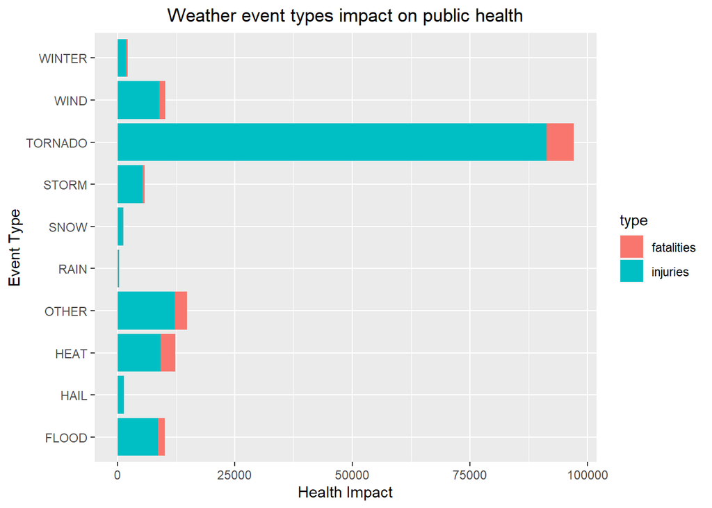

```r
#tranforming EVENT as a factor
agg.health$EVENT <- as.factor(agg.health$EVENT)

##plotting fatalities and injuries
health.plot <- ggplot(agg.health, aes(x = EVENT, y = Total, fill = type)) + geom_bar(stat = "identity") +
      coord_flip() +
      xlab("Event Type") +
      ylab("Health Impact") +
      ggtitle("Weather event types impact on public health") +
      theme(plot.title = element_text(hjust = 0.5))
print(health.plot)
```

The most harmful weather event for health (in number of total fatalites and injuries) is, by far, a **tornado**.

### Across the United States, which types of events are most harmful with respect to economics?

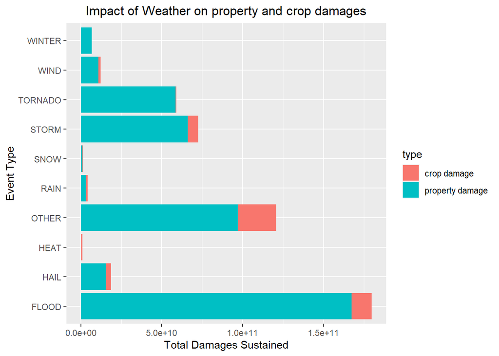

```r
##tranforming EVENT as a factor
agg.economic$EVENT <- as.factor(agg.economic$EVENT)

##plotting the damage
economic.plot <- ggplot(agg.economic, aes(x = EVENT, y = Total, fill = type)) + geom_bar(stat = "identity") +
      coord_flip() +
      xlab("Event Type") +
      ylab("Total Damages Sustained") +
      ggtitle("Impact of Weather on property and crop damages") +
      theme(plot.title = element_text(hjust = 0.5))
print(economic.plot)
```

The most devastating weather event with the greatest economic cosequences (to property and crops) is a **flood**.

## Conclusion

Hence as seen from the above analysis, Tornados are the biggest devastation for human life where as Floods are disrupt the economy more than all other Weather events.